# The bkmrhat package: diagnostics and multi-chain inference in Bayesian kernel machine regression

Alexander Keil

2025-11-19

## Introduction to `bkmr` and `bkmrhat`

`bkmr` is a package to implement Bayesian kernel machine regression (BKMR) using Markov chain Monte Carlo (MCMC). Notably, `bkmr` is missing some key features in Bayesian inference and MCMC diagnostics: 1) no facility for running multiple chains in parallel 2) no inference across multiple chains 3) limited posterior summary of parameters 4) limited diagnostics. The `bkmrhat` package is a lightweight set of function that fills in each of those gaps by enabling post-processing of `bkmr` output in other packages and building a small framework for parallel processing.

## How to use the `bkmrhat` package

1. Fit a BKMR model for a single chain using the `kmbaryes` function from `bkmr`, or use multiple parallel chains `kmbayes_parallel` from `bkmrhat`
2. Perform diagnostics on single or multiple chains using the `kmbayes_diagnose` function (uses functions from the `rstan` package) OR convert the BKMR fit(s) to `mcmc` (one chain) or `mcmc.list` (multiple chains) objects from the `coda` package using `as.mcmc` or `as.mcmc.list` from the `bkmrhat` package. The `coda` package has a whole host of inference and diagnostic procedures (but may lag behind some of the diagnostics functions from `rstan`).
3. Perform posterior summaries using `coda` functions or combine chains from a `kmbayes_parallel` fit using `kmbayes_combine`. Final posterior inferences can be made on the combined object, which enables use of `bkmr` package functions for visual summaries of independent and joint effects of exposures in the `bkmr` model.

First, simulate some data from the `bkmr` function

```r
library("bkmr")
library("bkmrhat")
library("coda")

set.seed(111)
dat <- bkmr::SimData(n = 50, M = 5, ind=1:3, Zgen="realistic")
y <- dat$y
Z <- dat$Z
X <- cbind(dat$X, rnorm(50))
head(cbind(y,Z,X))
```

```
##               y          z1          z2          z3          z4         z5
## [1,]  4.1379128 -0.06359282 -0.02996246 -0.14190647 -0.44089352 -0.1878732
## [2,] 12.0843607 -0.07308834  0.32021690  1.08838691  0.29448354 -1.4609837
## [3,]  7.8859254  0.59604857  0.20602329  0.46218114 -0.03387906 -0.7615902
## [4,]  1.1609768  1.46504863  2.48389356  1.39869461  1.49678590  0.2837234
## [5,]  0.4989372 -0.37549639  0.01159884  1.17891641 -0.05286516 -0.1680664
## [6,]  5.0731242 -0.36904566 -0.49744932 -0.03330522  0.30843805  0.6814844
##
## [1,]  1.0569172 -1.0503824
## [2,]  4.8158570  0.3251424
## [3,]  2.6683461 -2.1048716
## [4,] -0.7492096 -0.9551027
## [5,] -0.5428339 -0.5306399
## [6,]  1.6493251  0.8274405
```

### Example 1: single vs multi-chains

```r
# enable parallel processing (up to 4 simultaneous processes here)
future::plan(strategy = future::multisession)

# single run of 4000 observations from bkmr package
set.seed(111)
system.time(kmfit <- suppressMessages(kmbayes(y = y, Z = Z, X = X, iter = 4000, verbose = FALSE, varsel = FALSE)))
```

```
##    user  system elapsed
##   4.714   0.450   5.211
```

```r
# 4 runs of 1000 observations from bkmrhat package
set.seed(111)
system.time(kmfit5 <- suppressMessages(kmbayes_parallel(nchains=4, y = y, Z = Z, X = X, iter = 1000, verbose = FALSE, varsel = FALSE)))
```

```
## Chain 1
## Chain 2
## Chain 3
## Chain 4
```

```
##    user  system elapsed
##   0.359   0.048   9.585
```

### Example 2: Diagnostics

The diagnostics from the rstan package come from the `monitor` function (see the help files for that function in the rstan pacakge)

```r
# Using rstan functions (set burnin/warmup to zero for comparability with coda numbers given later
#  posterior summaries should be performed after excluding warmup/burnin)
singlediag = kmbayes_diagnose(kmfit, warmup=0, digits_summary=2)
```

```
## Single chain
```

```
## Inference for the input samples (1 chains: each with iter = 4000; warmup = 0):
##
##            Q5  Q50  Q95 Mean  SD  Rhat Bulk_ESS Tail_ESS
## beta1     1.9  2.0  2.1  2.0 0.0  1.00     2820     3194
## beta2     0.0  0.1  0.3  0.1 0.1  1.00     3739     3535
## lambda    3.9 10.0 22.3 11.2 5.9  1.00      346      222
## r1        0.0  0.0  0.1  0.0 0.1  1.01      129      173
## r2        0.0  0.0  0.1  0.0 0.1  1.00      182      181
## r3        0.0  0.0  0.0  0.0 0.0  1.01      158      112
## r4        0.0  0.0  0.1  0.0 0.1  1.03      176      135
## r5        0.0  0.0  0.0  0.0 0.1  1.00      107      114
## sigsq.eps 0.2  0.3  0.5  0.4 0.1  1.00     1262     1563
##
## For each parameter, Bulk_ESS and Tail_ESS are crude measures of
## effective sample size for bulk and tail quantities respectively (an ESS > 100
## per chain is considered good), and Rhat is the potential scale reduction
## factor on rank normalized split chains (at convergence, Rhat <= 1.05).
```

```r
# Using rstan functions (multiple chains enable R-hat)
multidiag = kmbayes_diagnose(kmfit5, warmup=0, digits_summary=2)
```

```
## Parallel chains
```

```
## Inference for the input samples (4 chains: each with iter = 1000; warmup = 0):
##
##            Q5 Q50  Q95 Mean  SD  Rhat Bulk_ESS Tail_ESS
## beta1     1.9 2.0  2.1  2.0 0.0  1.00     2334     1512
## beta2     0.0 0.1  0.3  0.1 0.1  1.00     3228     3643
## lambda    4.1 9.9 23.7 11.4 6.1  1.01      384      235
## r1        0.0 0.0  0.6  0.1 0.2  1.11       32       28
## r2        0.0 0.0  0.1  0.0 0.1  1.02      184      138
## r3        0.0 0.0  0.1  0.0 0.1  1.03      101       87
## r4        0.0 0.0  0.1  0.0 0.1  1.03      142       89
## r5        0.0 0.0  0.1  0.0 0.2  1.09       37       53
## sigsq.eps 0.2 0.3  0.5  0.3 0.1  1.00      899     1148
##
## For each parameter, Bulk_ESS and Tail_ESS are crude measures of
## effective sample size for bulk and tail quantities respectively (an ESS > 100
## per chain is considered good), and Rhat is the potential scale reduction
## factor on rank normalized split chains (at convergence, Rhat <= 1.05).
```

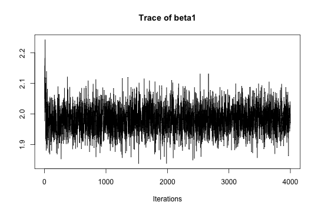

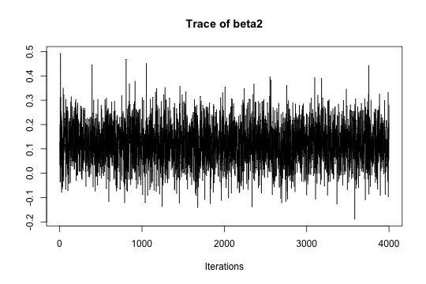

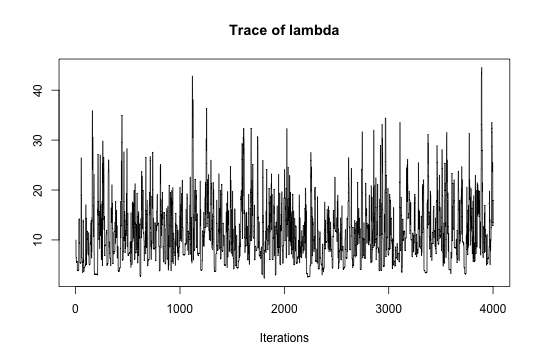

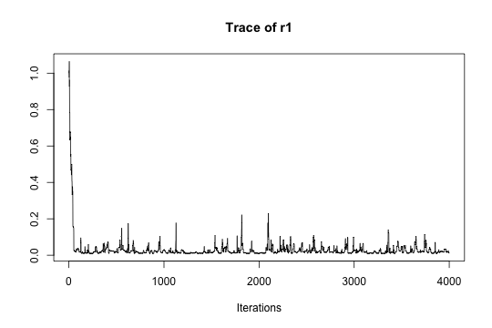

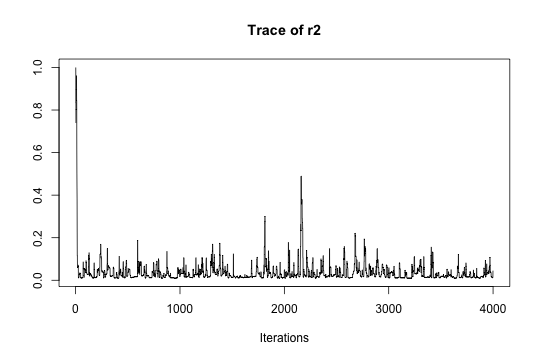

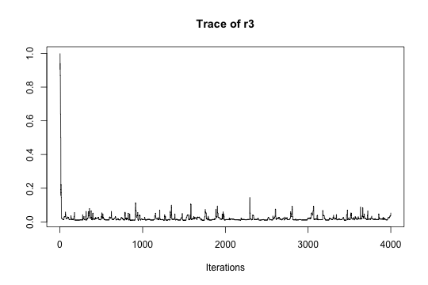

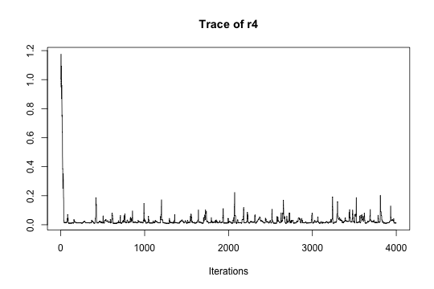

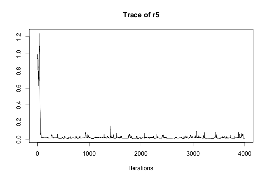

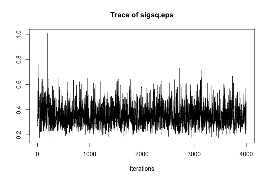

```r
# using coda functions, not using any burnin (for demonstration only)
kmfitcoda = as.mcmc(kmfit, iterstart = 1)
kmfit5coda = as.mcmc.list(kmfit5, iterstart = 1)

# single chain trace plot
traceplot(kmfitcoda)
```

The trace plots look typical, and fine, but trace plots don’t give a full picture of convergence. Note that there is apparent quick convergence for a couple of parameters demonstrated by movement away from the starting value and concentration of the rest of the samples within a narrow band.

Seeing visual evidence that different chains are sampling from the same marginal distributions is reassuring about the stability of the results.

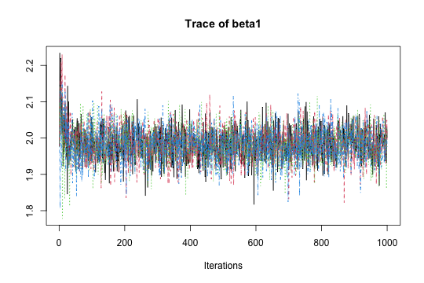

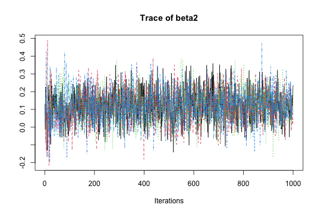

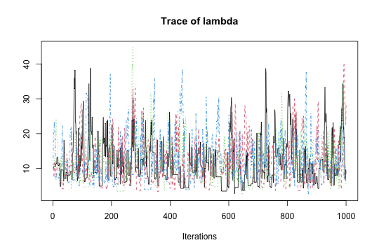

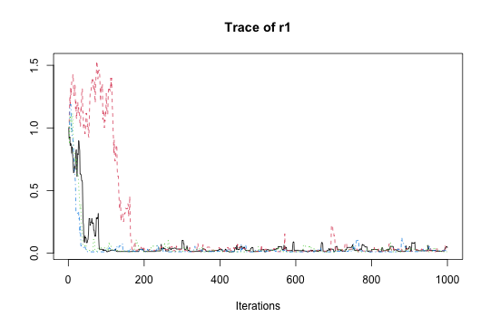

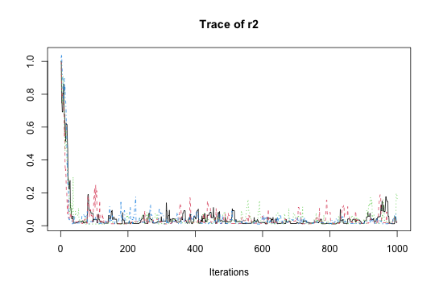

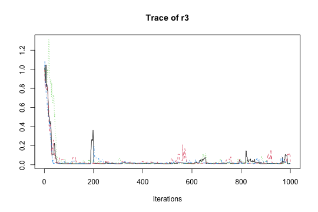

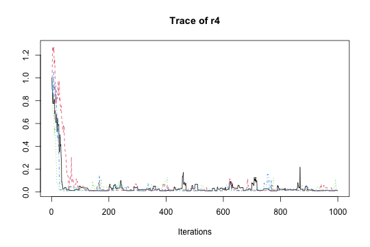

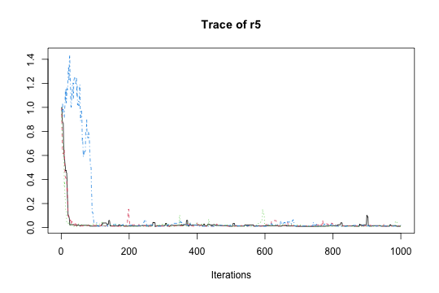

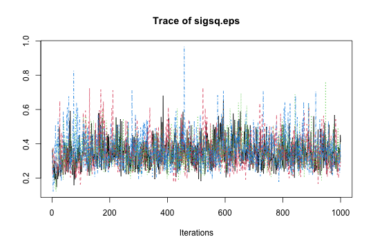

```r
# multiple chain trace plot
traceplot(kmfit5coda)
```

```r
# multiple cross-correlation plot (combines all samples)
crosscorr(kmfit5coda)
```

```
##                  beta1       beta2       lambda          r1          r2
## beta1      1.000000000  0.06063846  0.009619123  0.11863388  0.16213875
## beta2      0.060638461  1.00000000 -0.085205911 -0.08886474 -0.08044259
## lambda     0.009619123 -0.08520591  1.000000000 -0.03205822 -0.01564349
## r1         0.118633883 -0.08886474 -0.032058222  1.00000000  0.53623405
## r2         0.162138749 -0.08044259 -0.015643492  0.53623405  1.00000000
## r3         0.137314004 -0.05691727 -0.016089644  0.56704044  0.82325738
## r4         0.208176153 -0.07359633 -0.037404909  0.68444590  0.79050903
## r5         0.092149921 -0.05934214 -0.022712957  0.28395735  0.53975111
## sigsq.eps -0.029864448  0.04941527 -0.302048386 -0.13153370 -0.14208652
##                    r3          r4          r5   sigsq.eps
## beta1      0.13731400  0.20817615  0.09214992 -0.02986445
## beta2     -0.05691727 -0.07359633 -0.05934214  0.04941527
## lambda    -0.01608964 -0.03740491 -0.02271296 -0.30204839
## r1         0.56704044  0.68444590  0.28395735 -0.13153370
## r2         0.82325738  0.79050903  0.53975111 -0.14208652
## r3         1.00000000  0.74555066  0.46137436 -0.12123327
## r4         0.74555066  1.00000000  0.51099917 -0.11946345
## r5         0.46137436  0.51099917  1.00000000 -0.02434892
## sigsq.eps -0.12123327 -0.11946345 -0.02434892  1.00000000
```

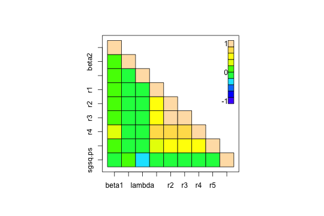

```r
crosscorr.plot(kmfit5coda)
```

Now examine “autocorrelation” to identify parameters that have high correlation between subsequent iterations of the MCMC sampler, which can lead to inefficient MCMC sampling. All other things equal, having highly autocorrelated parameters in the posterior means that more samples are needed than would be needed with low-autocorrelation parameters.

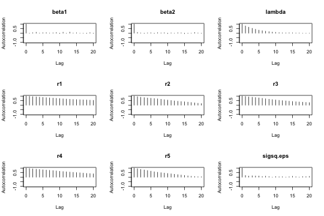

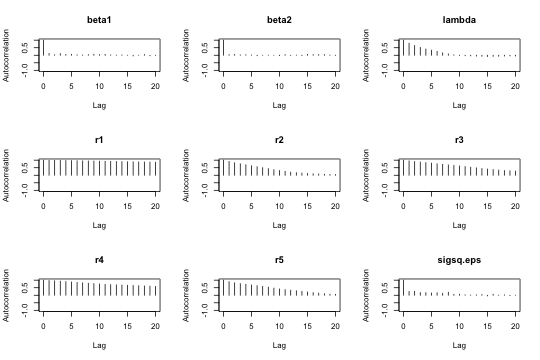

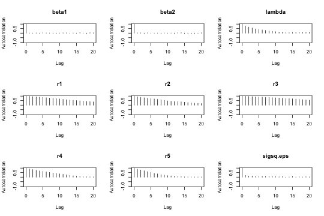

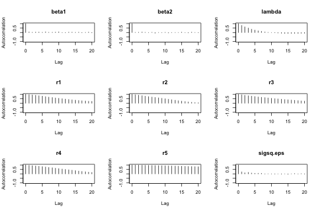

```r
# multiple chain trace plot
#autocorr(kmfit5coda) # lots of output
autocorr.plot(kmfit5coda)
```

Graphical tools can be limited, and are sometimes difficult to use effectively with scale parameters (of which `bkmr` has many). Additionally, no single diagnostic is perfect, leading many authors to advocate the use of multiple, complementary diagnostics. Thus, more formal diagnostics are helpful.

Gelman’s r-hat diagnostic gives an interpretable diagnostic: the expected reduction in the standard error of the posterior means if you could run the chains to an infinite size. These give some idea about when is a fine idea to stop sampling. There are rules of thumb about using r-hat to stop sampling that are available from several authors (for example you can consult the help files for `rstan` and `coda`).

Effective sample size is also useful - it estimates the amount of information in your chain, expressed in terms of the number of independent posterior samples it would take to match that information (e.g. if we could just sample from the posterior directly).

```r
# Gelman's r-hat using coda estimator (will differ from rstan implementation)
gelman.diag(kmfit5coda)
```

```
## Potential scale reduction factors:
##
##           Point est. Upper C.I.
## beta1           1.00       1.01
## beta2           1.00       1.00
## lambda          1.01       1.03
## r1              1.07       1.15
## r2              1.06       1.12
## r3              1.09       1.16
## r4              1.03       1.08
## r5              1.03       1.05
## sigsq.eps       1.00       1.00
##
## Multivariate psrf
##
## 1.04
```

```r
# effective sample size
effectiveSize(kmfitcoda)
```

```
##      beta1      beta2     lambda         r1         r2         r3         r4
## 2411.61996 2865.78264  431.49111   87.11091  260.29419  328.45388  181.61903
##         r5  sigsq.eps
##  123.06100 1719.70470
```

```r
effectiveSize(kmfit5coda)
```

```
##     beta1     beta2    lambda        r1        r2        r3        r4        r5
## 2585.9305 3682.2160  429.5677  100.1964  189.3471  120.6366  167.5633  181.6534
## sigsq.eps
## 1393.7627
```

### Example 3: Posterior summaries

Posterior kernel marginal densities, 1 chain

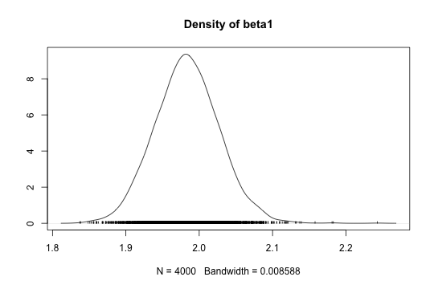

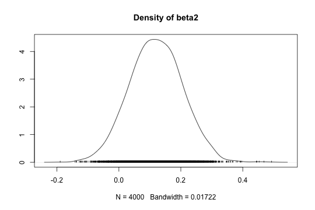

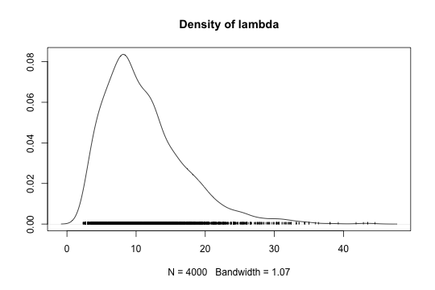

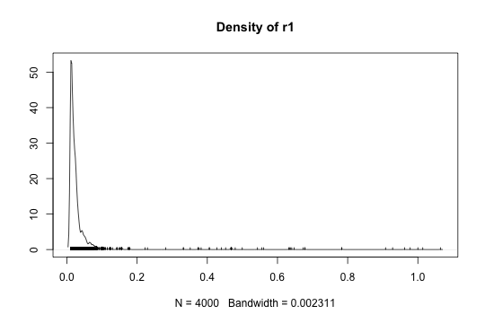

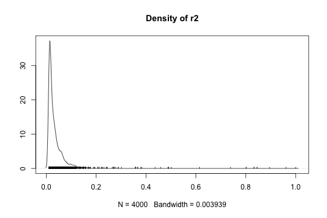

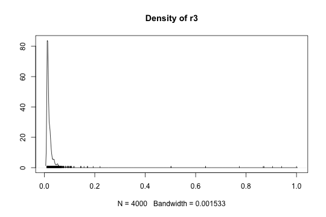

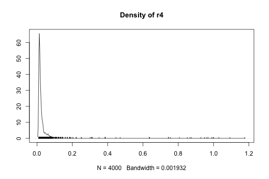

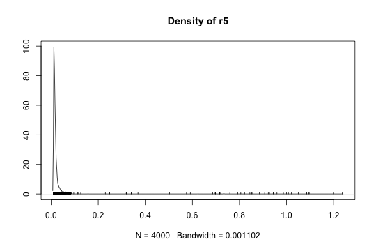

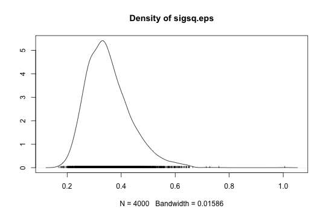

```r
# posterior kernel marginal densities using `mcmc` and `mcmc` objects
densplot(kmfitcoda)
```

Posterior kernel marginal densities, multiple chains combined. Look for multiple modes that may indicate non-convergence of some chains